# Quick overview of plot functions

Jacolien van Rij

2022-06-17

The table present the different plot functions in the packages **`mgcv`** (Wood 2006, 2011) and **`itsadug`** for visualizing GAMM models.

|  | Partial effect | Sum of all effects | Sum of “fixed” effects<sup>1</sup> |
| --- | --- | --- | --- |
| surface | `plot.gam()` | `vis.gam()` |  |
|  | `pvisgam()` | `fvisgam()` |  |
| smooth | `plot.gam()` | `plot_smooth()` |  |
| group estimates | `plot.gam()2` | `plot_parametric()` |  |
| random smooths | `get_random()`, `inspect_random()` |  |  |

<sup>1</sup>: include `rm.ranef=TRUE` to zero all random effects.

<sup>2</sup>: include `all.terms=TRUE` to visualize parametric terms.

# Examples

```r
library(itsadug)
library(mgcv)
data(simdat)

## Not run:
# Model with random effect and interactions:
m1 <- bam(Y ~ Group + te(Time, Trial, by=Group)
    + s(Time, Subject, bs='fs', m=1, k=5),
    data=simdat)
# Simple model with smooth:
m2 <-  bam(Y ~ Group + s(Time, by=Group)
    + s(Subject, bs='re')
    + s(Subject, Time, bs='re'),
    data=simdat)
```

Summary model `m1`:

```r
gamtabs(m1, type='html')
```

| A. parametric coefficients | Estimate | Std. Error | t-value | p-value |
| --- | --- | --- | --- | --- |
| (Intercept) | 2.0505 | 0.6881 | 2.9799 | 0.0029 |
| GroupAdults | 3.1204 | 0.9731 | 3.2065 | 0.0013 |
| B. smooth terms | edf | Ref.df | F-value | p-value |
| te(Time,Trial):GroupChildren | 19.7347 | 21.9398 | 1651.5571 | < 0.0001 |
| te(Time,Trial):GroupAdults | 19.6302 | 21.8781 | 1466.8432 | < 0.0001 |
| s(Time,Subject) | 175.2256 | 178.0000 | 5803.4508 | < 0.0001 |

Summary model `m2`:

```r
gamtabs(m2, type='html')
```

| A. parametric coefficients | Estimate | Std. Error | t-value | p-value |
| --- | --- | --- | --- | --- |
| (Intercept) | 2.0575 | 2.9497 | 0.6975 | 0.4855 |
| GroupAdults | 3.1264 | 4.1715 | 0.7495 | 0.4536 |
| B. smooth terms | edf | Ref.df | F-value | p-value |
| s(Time):GroupChildren | 8.6203 | 8.9584 | 1630.0297 | < 0.0001 |
| s(Time):GroupAdults | 8.8372 | 8.9921 | 8798.1199 | < 0.0001 |
| s(Subject) | 33.9912 | 34.0000 | 125335342.8798 | < 0.0001 |
| s(Subject,Time) | 33.9878 | 34.0000 | 125318454.9121 | < 0.0001 |

## a. Surfaces

Plotting the partial effects of `te(Time,Trial):GroupAdults` and `te(Time,Trial):GroupChildren`.

### pvisgam()

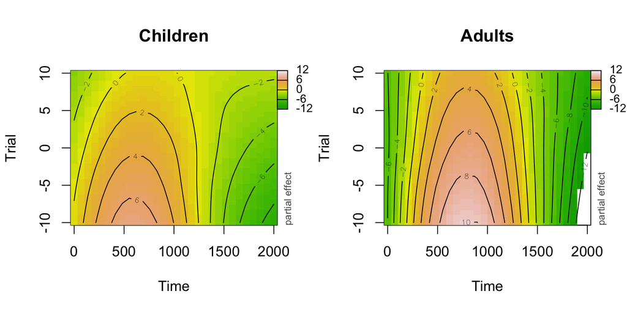

```r
par(mfrow=c(1,2), cex=1.1)

pvisgam(m1, view=c("Time", "Trial"), select=1,
        main="Children", zlim=c(-12,12))
pvisgam(m1, view=c("Time", "Trial"), select=2,
        main="Adults", zlim=c(-12,12))
```

Notes:

- Plots same data as `plot(m1, select=1)`: *partial effects plot*, i.e., the plot does not include intercept or any other effects.
- Make sure to set the zlim values the same when comparing surfaces
- Use the argument `cond` to specify the value of other predictors in a more complex interaction. For example, for plotting a modelterm `te(A,B,C)` use something like `pvisgam(model, view=c("A", "B"), select=1, cond=list(C=5))`.

### fvisgam()

Plotting the fitted effects of `te(Time,Trial):GroupAdults` and `te(Time,Trial):GroupChildren`.

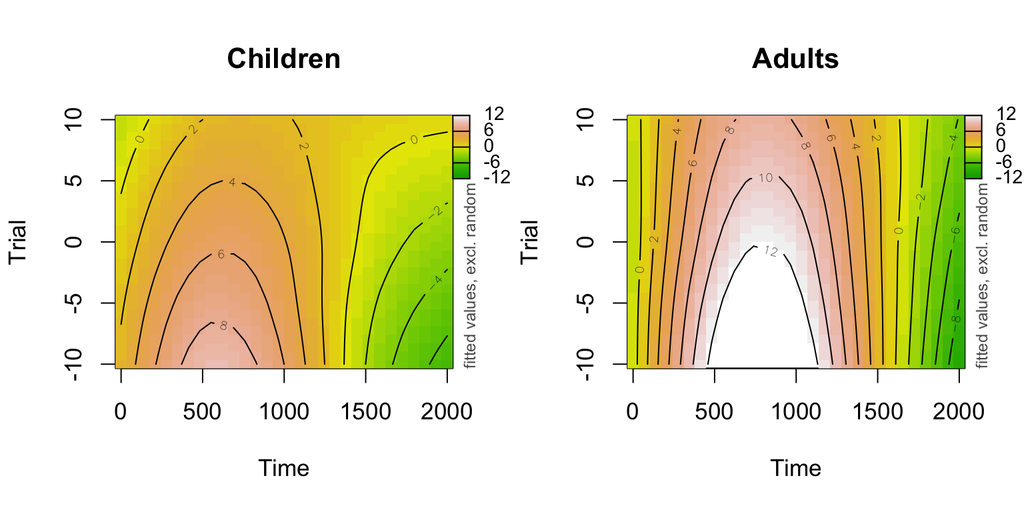

```r
par(mfrow=c(1,2), cex=1.1)

fvisgam(m1, view=c("Time", "Trial"), cond=list(Group="Children"),
        main="Children", zlim=c(-12,12), rm.ranef=TRUE)
fvisgam(m1, view=c("Time", "Trial"), cond=list(Group="Adults"),
        main="Adults", zlim=c(-12,12), rm.ranef=TRUE)
```

Notes:

- Plots the *fitted effects*, i.e., the plot includes intercept and estimates for the other modelterms.
- Make sure to set the zlim values the same when comparing surfaces
- Use the argument `cond` to specify the value of other predictors in the model.
- The argument `rm.ranef` cancels the contribution of random effects.
- The argument `transform` accepts a function for transforming the fitted values into the original scale.

## b. Smooths

### plot.gam()

Plotting the partial effects of `s(Time):GroupAdults` and `s(Time):GroupChildren`.

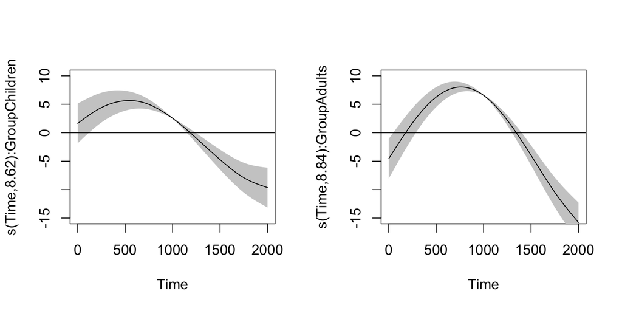

```r
par(mfrow=c(1,2), cex=1.1)

plot(m2, select=1, shade=TRUE, rug=FALSE, ylim=c(-15,10))
abline(h=0)
plot(m2, select=2, shade=TRUE, rug=FALSE, ylim=c(-15,10))
abline(h=0)
```

Notes:

- Not possible to combine different smooth terms in a single plot.

Alternatively:

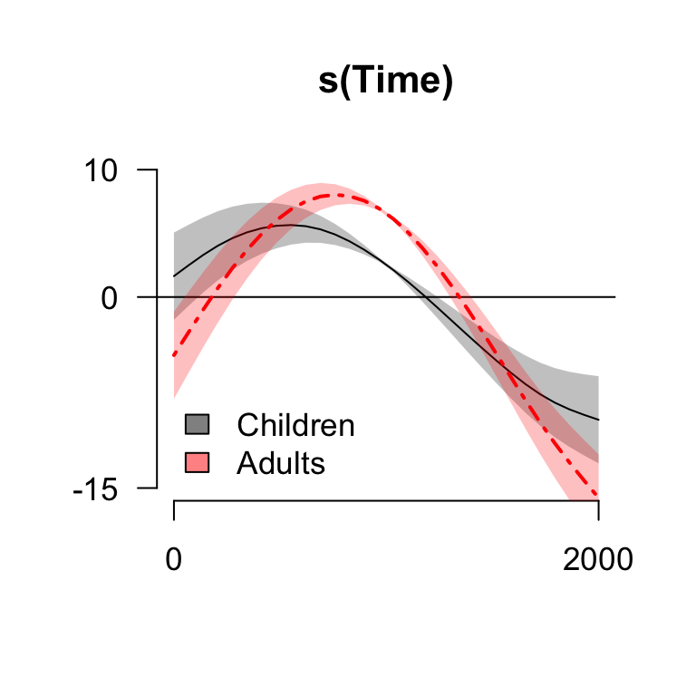

```r
par(mfrow=c(1,1), cex=1.1)

# Get model term data:
st1 <- get_modelterm(m2, select=1)
st2 <- get_modelterm(m2, select=2)

# plot model terms:
emptyPlot(2000, c(-15,10), h=0,
    main='s(Time)',
    xmark = TRUE, ymark = TRUE, las=1)
plot_error(st1$Time, st1$fit, st1$se.fit, shade=TRUE)
plot_error(st2$Time, st2$fit, st2$se.fit, shade=TRUE, col='red', lty=4, lwd=2)

# add legend:
legend('bottomleft',
  legend=c('Children', 'Adults'),
  fill=c(alpha('black'), alpha('red')),
  bty='n')
```

### plot_smooth()

Plotting the fitted effects of `te(Time,Trial):GroupAdults` and `te(Time,Trial):GroupChildren` i.e., the plot includes intercept and estimates for the other modelterms.

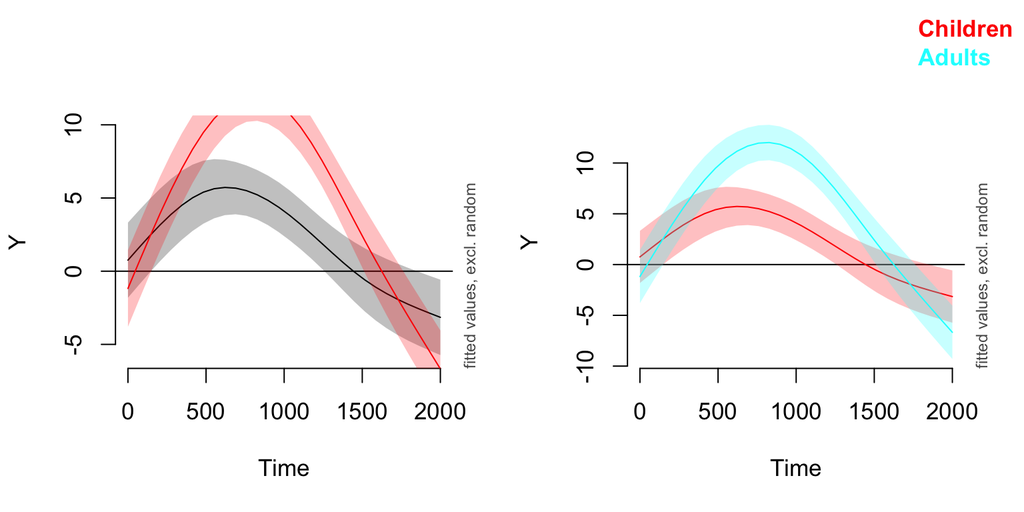

```r
par(mfrow=c(1,2), cex=1.1)

plot_smooth(m1, view="Time", cond=list(Group="Children"),
    rm.ranef=TRUE, ylim=c(-6,10))
plot_smooth(m1, view="Time", cond=list(Group="Adults"),
    col="red", rug=FALSE, add=TRUE,
    rm.ranef=TRUE)

# or alternatively:
plot_smooth(m1, view="Time", plot_all="Group",
    rm.ranef=TRUE)
```

Notes:

- Use the argument `cond` to specify the value of other predictors in the model.
- The argument `rm.ranef` cancels the contribution of random effects.
- The argument `transform` accepts a function for transforming the fitted values into the original scale.
- The argument `plot_all` plots all levels for the given predictor(s).

## c. Group estimates

### plot.gam()

Plotting the partial effect of grouping predictors such as `Group`:

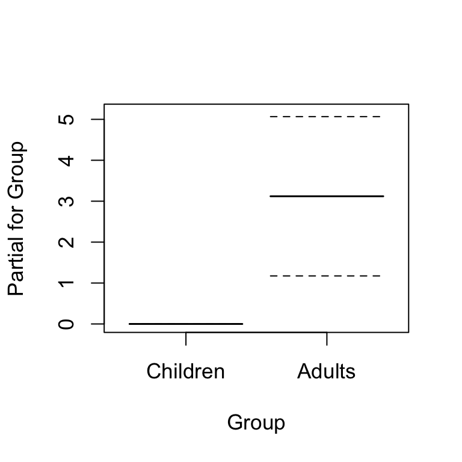

```r
par(mfrow=c(1,1), cex=1.1)

plot.gam(m1, select=4, all.terms=TRUE, rug=FALSE)
```

Alternatively, use `get_coefs()` to extract the coefficients and plot these:

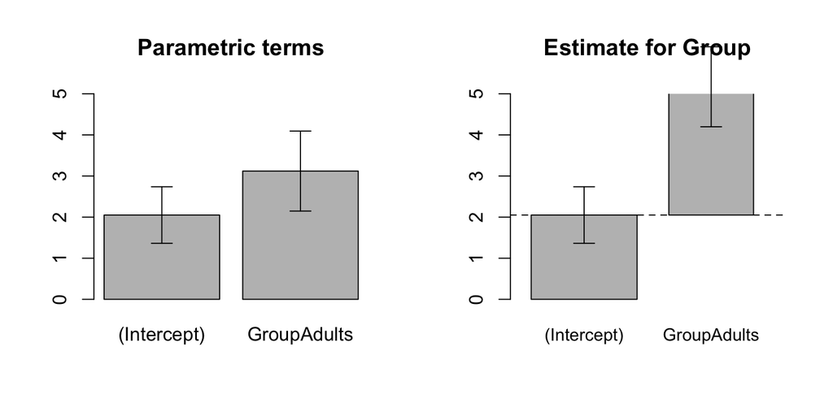

```
##             Estimate Std. Error
## (Intercept) 2.050539  0.6881195
## GroupAdults 3.120351  0.9731479
```

```r
coefs <- get_coefs(m1)
coefs

par(mfrow=c(1,2), cex=1.1)

b <- barplot(coefs[,1], beside=TRUE,
             main="Parametric terms",
             ylim=c(0,5))
errorBars(b, coefs[,1], coefs[,2], xpd=TRUE)

# Note that the effect of Group is a *difference* estimate
# between intercept (=GroupChildren) and Group Adults

b2 <- barplot(coefs[1,1], beside=TRUE,
             main="Estimate for Group",
             ylim=c(0,5), xlim=c(0.1,2.5))
mtext(row.names(coefs), at=b, side=1, line=1)
abline(h=coefs[1,1], lty=2)
rect(b[2]-.4, coefs[1,1], b[2]+.4, coefs[1,1]+coefs[2,1],
     col='gray')
errorBars(b, coefs[,1]+c(0,coefs[1,1]), coefs[,2], xpd=TRUE)
```

Notes:

- For large models `get_coefs()` is faster than `summary(model)`.

### plot_parametric()

Plotting the fitted effects of grouping predictors such as `Group`:

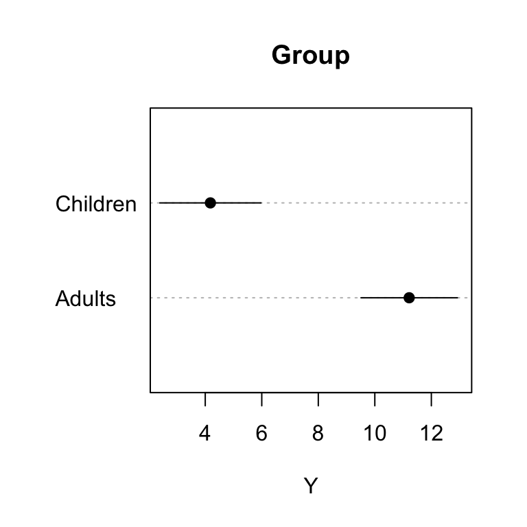

```r
pp <- plot_parametric(m1, pred=list(Group=c("Children", "Adults")) )
```

```r
pp
```

```
## $fv
##      Group    Time Trial Subject       fit       CI        rm.ranef
## 1 Children 989.899     0     a01  4.182214 1.705797 s(Time,Subject)
## 2   Adults 989.899     0     a01 11.216176 1.789386 s(Time,Subject)
```

## Random effects

### get_random()

For extracting the random effects coefficients (random adjustments of intercept and slopes):

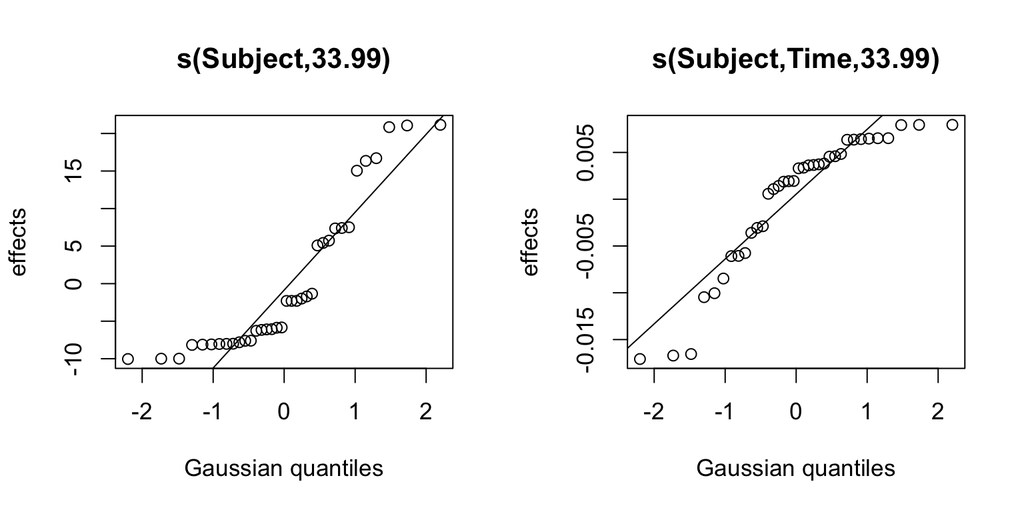

```r
par(mfrow=c(1,2), cex=1.1)
plot(m2, select=3)
plot(m2, select=4)
```

Or alternatively:

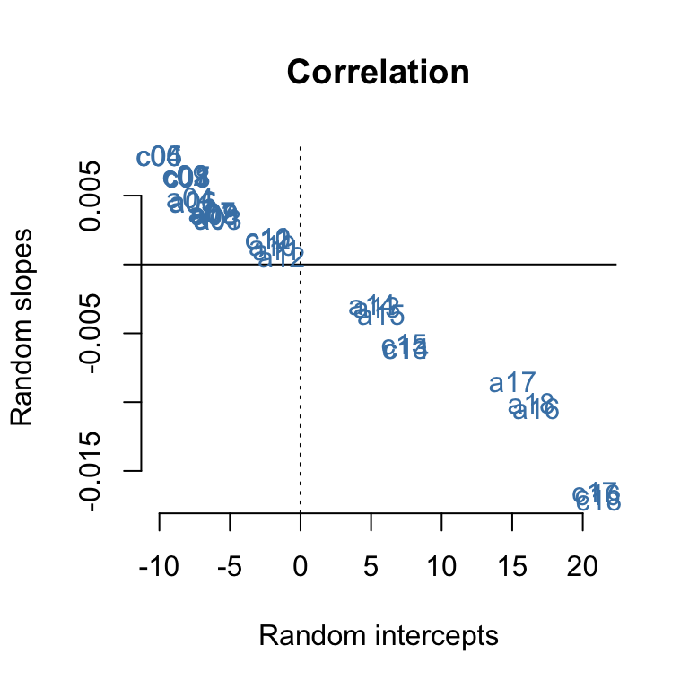

```r
pp <- get_random(m2)

emptyPlot(range(pp[[1]]), range(pp[[2]]), h=0,v=0,
     xlab='Random intercepts', ylab='Random slopes',
     main='Correlation')

text(pp[[1]], pp[[2]], labels=names(pp[[1]]),
     col='steelblue', xpd=TRUE)
```

### inspect_random()

For plotting and extracting the random smooths:

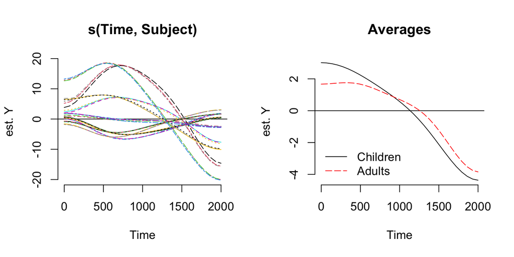

```r
par(mfrow=c(1,2), cex=1.1)

inspect_random(m1, select=3, main='s(Time, Subject)')

children <- unique(simdat[simdat$Group=="Children", "Subject"])
adults   <- unique(simdat[simdat$Group=="Adults", "Subject"])

inspect_random(m1, select=3, main='Averages',
      fun=mean,
      cond=list(Subject=children))
inspect_random(m1, select=3,
      fun=mean, cond=list(Subject=adults),
      add=TRUE, col='red', lty=5)

# add legend:
legend('bottomleft',
  legend=c('Children', 'Adults'),
  col=c('black', 'red'), lty=c(1,5),
  bty='n')
```

# References

Wood, Simon N. 2006. *Generalized Additive Models: An Introduction with R*. Chapman; Hall/CRC.

———. 2011. “Fast Stable Restricted Maximum Likelihood and Marginal Likelihood Estimation of Semiparametric Generalized Linear Models.” *Journal of the Royal Statistical Society (B)* 73 (1): 3–36.